# Project 1: Wrangling, Exploration, Visualization

#### Tidying: Reshaping

```r
#
view(Fatalities)
arrange(Fatalities, across(everything(), desc))
```

```
## # A tibble: 336 × 35
##       X1 state  year spirits unemp income emppop beertax baptist mormon drinkage
##    <dbl> <chr> <dbl>   <dbl> <dbl>  <dbl>  <dbl>   <dbl>   <dbl>  <dbl>    <dbl>
##  1   336 wy     1988    1.55  6.30 13098.   64.6  0.0433   3.01   8.51      19.5
##  2   335 wy     1987    1.59  8.60 12719    62.9  0.0450   2.91   8.52      19
##  3   334 wy     1986    1.70  9    13127.   64.0  0.0464   2.81   8.53      19
##  4   333 wy     1985    1.88  7.10 13595.   65.1  0.0477   2.72   8.54      19
##  5   332 wy     1984    1.91  6.30 13456.   66.0  0.0495   2.63   8.56      19
##  6   331 wy     1983    1.99  8.40 13575.   66.4  0.0516   2.54   8.57      19
##  7   330 wy     1982    2.19  5.80 14600.   67.3  0.0537   2.46   8.58      19
##  8   329 wi     1988    1.65  4.30 14941.   67.4  0.140    0.370  0.370     21
##  9   328 wi     1987    1.68  6.10 14720    64.7  0.145    0.343  0.343     21
## 10   327 wi     1986    1.75  7    14352.   62.2  0.150    0.317  0.317     19.7
## # … with 326 more rows, and 24 more variables: dry <dbl>, youngdrivers <dbl>,
## #   miles <dbl>, breath <chr>, jail <chr>, service <chr>, fatal <dbl>,
## #   nfatal <dbl>, sfatal <dbl>, fatal1517 <dbl>, nfatal1517 <dbl>,
## #   fatal1820 <dbl>, nfatal1820 <dbl>, fatal2124 <dbl>, nfatal2124 <dbl>,
## #   afatal <dbl>, pop <dbl>, pop1517 <dbl>, pop1820 <dbl>, pop2124 <dbl>,
## #   milestot <dbl>, unempus <dbl>, emppopus <dbl>, gsp <dbl>
```

```r
Fatality = select(Fatality, -c(state))

Fatalities %>% mutate(Fatalities, unrate = unemp) %>% mutate(Fatalities,
    vmiles = miles) %>% mutate(Fatalities, jaild = jail) %>%
    mutate(Fatalities, mlda = drinkage) %>% mutate(Fatalities,
    comserd = service) %>% mutate(Fatalities, perinc = income)
```

```
## # A tibble: 336 × 41
##       X1 state  year spirits unemp income emppop beertax baptist mormon drinkage
##    <dbl> <chr> <dbl>   <dbl> <dbl>  <dbl>  <dbl>   <dbl>   <dbl>  <dbl>    <dbl>
##  1     1 al     1982    1.37 14.4  10544.   50.7   1.54    30.4   0.328     19
##  2     2 al     1983    1.36 13.7  10733.   52.1   1.79    30.3   0.343     19
##  3     3 al     1984    1.32 11.1  11109.   54.2   1.71    30.3   0.359     19
##  4     4 al     1985    1.28  8.90 11333.   55.3   1.65    30.3   0.376     19.7
##  5     5 al     1986    1.23  9.80 11662.   56.5   1.61    30.3   0.393     21
##  6     6 al     1987    1.18  7.80 11944    57.5   1.56    30.2   0.411     21
##  7     7 al     1988    1.17  7.20 12369.   56.8   1.50    30.2   0.430     21
##  8     8 az     1982    1.97  9.90 12309.   56.9   0.215    3.96  4.92      19
##  9     9 az     1983    1.90  9.10 12694.   57.6   0.206    3.89  4.83      19
## 10    10 az     1984    2.14  5    13266.   60.4   0.297    3.82  4.74      19
## # … with 326 more rows, and 30 more variables: dry <dbl>, youngdrivers <dbl>,
## #   miles <dbl>, breath <chr>, jail <chr>, service <chr>, fatal <dbl>,
## #   nfatal <dbl>, sfatal <dbl>, fatal1517 <dbl>, nfatal1517 <dbl>,
## #   fatal1820 <dbl>, nfatal1820 <dbl>, fatal2124 <dbl>, nfatal2124 <dbl>,
## #   afatal <dbl>, pop <dbl>, pop1517 <dbl>, pop1820 <dbl>, pop2124 <dbl>,
## #   milestot <dbl>, unempus <dbl>, emppopus <dbl>, gsp <dbl>, unrate <dbl>,
## #   vmiles <dbl>, jaild <chr>, mlda <dbl>, comserd <chr>, perinc <dbl>
```

```r
arrange(Fatality, across(everything(), desc))
```

```
## # A tibble: 336 × 10
##       X1  year mrall beertax  mlda jaild comserd vmiles unrate perinc
##    <dbl> <dbl> <dbl>   <dbl> <dbl> <chr> <chr>    <dbl>  <dbl>  <dbl>
##  1   336  1988  3.24  0.0433  19.5 yes   no       11.8    6.30 13098.
##  2   335  1987  2.63  0.0450  19   yes   no       11.0    8.60 12719
##  3   334  1986  3.31  0.0464  19   yes   no       10.6    9    13127.
##  4   333  1985  2.99  0.0477  19   yes   no       10.6    7.10 13595.
##  5   332  1984  3.06  0.0495  19   yes   no        9.99   6.30 13456.
##  6   331  1983  3.35  0.0516  19   yes   no        9.80   8.40 13575.
##  7   330  1982  3.94  0.0537  19   yes   no       10.4    5.80 14600.
##  8   329  1988  1.66  0.140   21   no    no        8.75   4.30 14941.
##  9   328  1987  1.66  0.145   21   no    no        8.36   6.10 14720
## 10   327  1986  1.56  0.150   19.7 no    no        8.04   7    14352.
## # … with 326 more rows
```

```r
Fatalities %>% na.omit()
```

```
## # A tibble: 335 × 35
##       X1 state  year spirits unemp income emppop beertax baptist mormon drinkage
##    <dbl> <chr> <dbl>   <dbl> <dbl>  <dbl>  <dbl>   <dbl>   <dbl>  <dbl>    <dbl>
##  1     1 al     1982    1.37 14.4  10544.   50.7   1.54    30.4   0.328     19
##  2     2 al     1983    1.36 13.7  10733.   52.1   1.79    30.3   0.343     19
##  3     3 al     1984    1.32 11.1  11109.   54.2   1.71    30.3   0.359     19
##  4     4 al     1985    1.28  8.90 11333.   55.3   1.65    30.3   0.376     19.7
##  5     5 al     1986    1.23  9.80 11662.   56.5   1.61    30.3   0.393     21
##  6     6 al     1987    1.18  7.80 11944    57.5   1.56    30.2   0.411     21
##  7     7 al     1988    1.17  7.20 12369.   56.8   1.50    30.2   0.430     21
##  8     8 az     1982    1.97  9.90 12309.   56.9   0.215    3.96  4.92      19
##  9     9 az     1983    1.90  9.10 12694.   57.6   0.206    3.89  4.83      19
## 10    10 az     1984    2.14  5    13266.   60.4   0.297    3.82  4.74      19
## # … with 325 more rows, and 24 more variables: dry <dbl>, youngdrivers <dbl>,
## #   miles <dbl>, breath <chr>, jail <chr>, service <chr>, fatal <dbl>,
## #   nfatal <dbl>, sfatal <dbl>, fatal1517 <dbl>, nfatal1517 <dbl>,
## #   fatal1820 <dbl>, nfatal1820 <dbl>, fatal2124 <dbl>, nfatal2124 <dbl>,
## #   afatal <dbl>, pop <dbl>, pop1517 <dbl>, pop1820 <dbl>, pop2124 <dbl>,
## #   milestot <dbl>, unempus <dbl>, emppopus <dbl>, gsp <dbl>
```

```r
Fatality %>% na.omit()
```

```
## # A tibble: 336 × 10
##       X1  year mrall beertax  mlda jaild comserd vmiles unrate perinc
##    <dbl> <dbl> <dbl>   <dbl> <dbl> <chr> <chr>    <dbl>  <dbl>  <dbl>
##  1     1  1982  2.13   1.54   19   no    no        7.23  14.4  10544.
##  2     2  1983  2.35   1.79   19   no    no        7.84  13.7  10733.
##  3     3  1984  2.34   1.71   19   no    no        8.26  11.1  11109.
##  4     4  1985  2.19   1.65   19.7 no    no        8.73   8.90 11333.
##  5     5  1986  2.67   1.61   21   no    no        8.95   9.80 11662.
##  6     6  1987  2.72   1.56   21   no    no        9.17   7.80 11944
##  7     7  1988  2.49   1.50   21   no    no        9.67   7.20 12369.
##  8     8  1982  2.50   0.215  19   yes   yes       6.81   9.90 12309.
##  9     9  1983  2.27   0.206  19   yes   yes       6.59   9.10 12694.
## 10    10  1984  2.83   0.297  19   yes   yes       6.71   5    13266.
## # … with 326 more rows
```

#### Joining/Merging

```r
#
anti_join(Fatalities, Fatality, by = "year") %>% summarize(n_distinct(year))
```

```
## # A tibble: 1 × 1
##   `n_distinct(year)`
##                <int>
## 1                  0
```

```r
anti_join(Fatality, Fatalities, by = "year") %>% summarize(n_distinct(year))
```

```
## # A tibble: 1 × 1
##   `n_distinct(year)`
##                <int>
## 1                  0
```

```r
inner_join(Fatalities, Fatality, by = "year") %>% summarize(n_distinct(year))
```

```
## # A tibble: 1 × 1
##   `n_distinct(year)`
##                <int>
## 1                  7
```

```r
full_join <- left_join(Fatality, Fatalities, by = "year")
```

When anti_joining the two datasets to find the number of distinct values of the ID variable, in this case, “year,” we find that there are 0 distinct years in “Fatality” dataset that are not in the “Fatalities” dataset and vice versa. This makes sense because both our datasets have 336 observations and 7 distinct ID variables. Each dataset involves data from 1982-1988.

#### Wrangling

```r
#

full_join %>% summarize(mean_miles = mean(miles), sd_miles = sd(miles),
    max_miles = max(miles), min_miles = min(miles), n())
```

```
## # A tibble: 1 × 5
##   mean_miles sd_miles max_miles min_miles `n()`
##        <dbl>    <dbl>     <dbl>     <dbl> <int>
## 1      7891.    1474.    26148.     4576. 16128
```

```r
median(full_join$miles)
```

```
## [1] 7796.219
```

```r
full_join %>% summarize(mean_unrate = mean(unrate), sd_unrate = sd(unrate),
    max_unrate = max(unrate), min_unrate = min(unrate), n())
```

```
## # A tibble: 1 × 5
##   mean_unrate sd_unrate max_unrate min_unrate `n()`
##         <dbl>     <dbl>      <dbl>      <dbl> <int>
## 1        7.35      2.53         18       2.40 16128
```

```r
median(full_join$unrate)
```

```
## [1] 7
```

```r
full_join %>% summarize(mean_mlda = mean(mlda), sd_mlda = sd(mlda),
    max_mlda = max(mlda), min_mlda = min(mlda), n())
```

```
## # A tibble: 1 × 5
##   mean_mlda sd_mlda max_mlda min_mlda `n()`
##       <dbl>   <dbl>    <dbl>    <dbl> <int>
## 1      20.5   0.898       21       18 16128
```

```r
median(full_join$mlda)
```

```
## [1] 21
```

```r
full_join %>% summarize(mean_perinc = mean(perinc), sd_perinc = sd(perinc),
    max_perinc = max(perinc), min_perinc = min(perinc), n())
```

```
## # A tibble: 1 × 5
##   mean_perinc sd_perinc max_perinc min_perinc `n()`
##         <dbl>     <dbl>      <dbl>      <dbl> <int>
## 1      13880.     2250.     22193.      9514. 16128
```

```r
median(full_join$perinc)
```

```
## [1] 13763.13
```

```r
full_join %>% mutate(fatalrate = fatal/10000)
```

```
## # A tibble: 16,128 × 45
##     X1.x  year mrall beertax.x  mlda jaild comserd vmiles unrate perinc  X1.y
##    <dbl> <dbl> <dbl>     <dbl> <dbl> <chr> <chr>    <dbl>  <dbl>  <dbl> <dbl>
##  1     1  1982  2.13      1.54    19 no    no        7.23   14.4 10544.     1
##  2     1  1982  2.13      1.54    19 no    no        7.23   14.4 10544.     8
##  3     1  1982  2.13      1.54    19 no    no        7.23   14.4 10544.    15
##  4     1  1982  2.13      1.54    19 no    no        7.23   14.4 10544.    22
##  5     1  1982  2.13      1.54    19 no    no        7.23   14.4 10544.    29
##  6     1  1982  2.13      1.54    19 no    no        7.23   14.4 10544.    36
##  7     1  1982  2.13      1.54    19 no    no        7.23   14.4 10544.    43
##  8     1  1982  2.13      1.54    19 no    no        7.23   14.4 10544.    50
##  9     1  1982  2.13      1.54    19 no    no        7.23   14.4 10544.    57
## 10     1  1982  2.13      1.54    19 no    no        7.23   14.4 10544.    64
## # … with 16,118 more rows, and 34 more variables: state <chr>, spirits <dbl>,
## #   unemp <dbl>, income <dbl>, emppop <dbl>, beertax.y <dbl>, baptist <dbl>,
## #   mormon <dbl>, drinkage <dbl>, dry <dbl>, youngdrivers <dbl>, miles <dbl>,
## #   breath <chr>, jail <chr>, service <chr>, fatal <dbl>, nfatal <dbl>,
## #   sfatal <dbl>, fatal1517 <dbl>, nfatal1517 <dbl>, fatal1820 <dbl>,
## #   nfatal1820 <dbl>, fatal2124 <dbl>, nfatal2124 <dbl>, afatal <dbl>,
## #   pop <dbl>, pop1517 <dbl>, pop1820 <dbl>, pop2124 <dbl>, milestot <dbl>, …
```

#### Visualizing

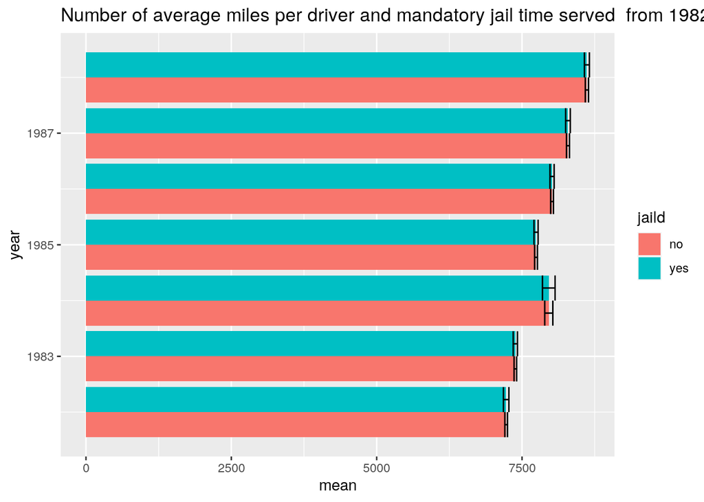

```r
#
full_join %>% select(year, jaild, miles) %>% na.omit %>% group_by(year,
    jaild) %>% summarize(mean = mean(miles), se = sd(miles)/sqrt(n())) %>%
    ggplot(aes(year, mean, fill = jaild)) + geom_bar(stat = "identity",
    position = "dodge") + geom_errorbar(aes(ymin = mean - se,
    ymax = mean + se), position = "dodge") + coord_flip() + ggtitle("Number of average miles per driver and mandatory jail time served  from 1982 to 1988")
```

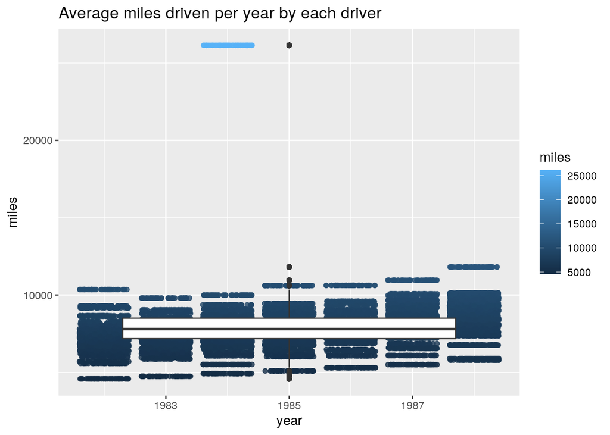

```r
#
ggplot(full_join, aes(x = year, y = miles)) + geom_jitter(alpha = 0.8,
    aes(color = miles)) + geom_boxplot() + ggtitle("Average miles driven per year by each driver")
```

In this plot, while using the ggplot function, we used the jeom_jitter function before the geom_boxplot function in order to see the boxplot clearly. This graph further shows that as the year increases, the number of miles driven also increases.

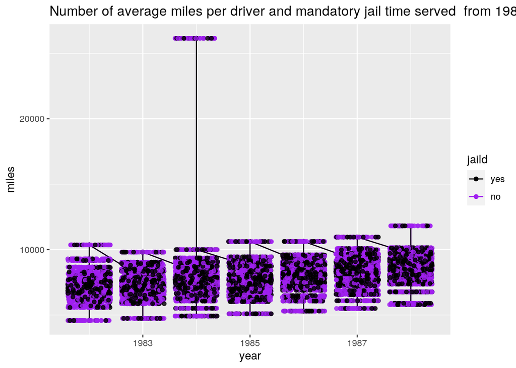

```r
#
ggplot(data = full_join, aes(x = year, y = miles, color = jaild)) +
    geom_point(size = 1.5) + xlab("year") + geom_line() + ylab("miles") +
    scale_color_manual(values = c(yes = "black", no = "purple")) +
    ggtitle("Number of average miles per driver and mandatory jail time served  from 1982 to 1988 ") +
    geom_jitter(alpha = 0.8)
```